# EAE6030 - Econometria II

Prof: Pedro Forquesato pforquesato@usp.br Faculdade de Economia, Administração e Contabilidade Universidade de São Paulo

Segundo bimestre de 2020

# Programa

Esta é a segunda parte da seqüência básica de cursos de econometria do programa de pós-graduação do Departamento de Economia da FEA-USP. Esta segunda parte cobre métodos de estimação de modelos não lineares e aplicações. O curso requer familiaridade com o material coberto em Econometria I e seus pré-requisitos.

### Conteúdo e calendário

1. [05/05 e 07/05] A teoria dos estimadores de extremo. Consistência e normalidade assintótica. Testes de hipótese. Exemplo: estimadores de mínimos quadrados não lineares.
2. [12, 14 e 19/05] O estimador de máxima-verossimilhança. Eficiência assintótica e a igualdade da matriz informacional. Teste de razão de verossimilhança.
3. [21, 26 e 28/05] Modelos de resposta discreta. Modelos binomial (logit e probit) e multinomial.
4. [02 e 04/06] Modelos de resposta truncada (tobit tipo I, tobit tipo II).
5. [09, 16 e 18/06] O método dos momentos generalizados para equações estruturais lineares e não lineares. A matriz de pesos ótima e testes de sobreidentificação.
6. [23/06] Bootstrap.

Obs: as datas acima são aproximadas, e dependem da velocidade da turma.

**Data da prova:** 25/06. **Data final de entrega de listas:** 12/07.

### Bibliografia

- Estimadores de extremo (M-estimation). Wooldridge: cap.12 (12.1-12.3; 12.5-12.7).
- Máxima Verossimilhança. Wooldridge: cap. 13 (13.1-13.7; 13.11).
- Modelos de resposta discreta. Wooldridge: cap. 15 (15.1-15.7); cap. 16 (16.1-16.3).
- Modelos censurados. Wooldridge: cap. 17 (17.1-17.6).
- GMM. Wooldridge: caps. 8 e 14 (14.1-14.5).
- Bootstrap. Cameron & Trivedi: cap. 11.

Os livros citados acima são:

- Wooldridge, Jeffrey M. Econometric analysis of cross section and panel data. MIT press, 2010. (2ª edição.)
- Cameron, A. Colin, and Pravin K. Trivedi. Microeconometrics: methods and applications. Cambridge university press, 2005.

Outros livros potencialmente úteis:

- Hayashi, Fumio. Econometrics. Princeton University Press, 2000.
- Greene, William H. Econometric Analysis. Prentice Hall, 6th edition, 2008.
- Newey, W.K. And Mcfadden, D.L. Large sample estimation and hypothesis testing. In: Handbook of Econometrics, vol IV, ch. 36, 1994.

### Avaliação

Uma prova, 3 (três) listas de exercício e 3 (três) listas aplicadas.

Listas de exercício serão avaliadas em satisfatórias (S) ou não-satisfatórias (NS). Listas *entregues na data certa* (para listas 1 e 2) serão corrigidas e devolvidas, e se consideradas NS, podem ser refeitas. Todas as listas (originais ou refeitas) podem ser entregues até duas semanas depois da prova final. *Não serão aceitas listas de exercício entregues após a definição dos conceitos*.

Para a obtenção do conceito A é obrigatória a entrega de **todas** as listas de exercício e listas aplicadas (com avaliação S). Para alunos sem desempenho ótimo na prova, a entrega de **todas** as listas (com avaliação S) também é pré-requisito para a aprovação no curso.

*O plágio de listas é absolutamente inaceitável* e acarretará avaliação NS não-retratável na lista.

### Office Hours

Agendamento por e-mail. (Ou passar na sala 19C/FEA2 e ver se eu estou lá.) O Moodle não será usado para comunicação do curso.

# Lista 1

### M-Estimadores parte I: least absolute deviations (LAD)

Considere o problema de estimar os parâmetros verdadeiros $\theta_0$ que satisfazem uma equação estrutural para a mediana de $Y | X = x$ : $Med(Y | X = x) = x \theta_0$, onde $x$ contém uma constante.

1. Mostre que $\theta_0$ minimiza $\mathbb{E}_Y\left[ \left| Y - X \theta \right| | X = x\right]$ sobre $\theta \in \Theta$.
2. Use (a) (e o princípio da analogia) para derivar um estimador-M para $\theta_0$. Esse é o estimador LAD. (Torcemos.)
3. Mostre se podemos (ou não) aplicar os Teoremas vistos em sala para afirmar a consistência e normalidade assintótica do estimador de LAD. Precisamos de suposições adicionais para obter esses resultados? Quais?
4. Assuma consistência e normalidade assintótica. Calcule o score e mostre que a esperança condicional do score é zero.
5. Qual é a Hessiana da função objetivo (onde é definida)? (Mesmo assim) calcule a variância assintótica do estimador de LAD.

### M-Estimadores parte II: teste de score (ou de multiplicador de Lagrange - LM).

Seja um M-estimador obtido pela solução do análogo amostral de $\theta_0 = \text{arg} \min_{\theta} \mathbb{E}\left[ q(W, \theta) \right]$, isto é:
$$\hat{\theta} = \text{arg}\min_{\theta} \frac{1}{N} \sum_{i=1}^N q(w_i, \theta)$$

Considere $Q$ restrições $c(\theta)$, e escreva-as da forma $d: \mathbb{R}^{P-Q} \rightarrow \mathbb{R}^P$, onde $P$ é a dimensão do vetor de parâmetros e $Q$ o número de restrições $C^1$, isto é, $H_0 : \theta_0 = d(\lambda_0)$, de dimensão $P-Q$.

Se $\tilde{\lambda}$ é a solução do problema restringido:
$$\min_\lambda \frac{1}{N} \sum_{i=1}^N q(w_i, d(\lambda)),$$
e $d(\tilde{\lambda}) \equiv \tilde{\theta}$, então o teste de score parte do princípio que pelas condições de primeira ordem:
$$\frac{1}{N} \sum_{i=1}^N s(w_i, \hat{\theta}) = 0.$$

Então se as restrições são válidas (i.e., sob a hipótese nula), também deve ser verdade que:
$$S \equiv N^{-1} \sum_{i=1}^N s(w_i, \tilde{\theta}) \sim 0.$$

Derive: 1. O limite assintótico de $S$. 2. A variância assintótica de $S$ e a estatística de score LM, obtida a partir de $S$ e que segue distribuição chi-quadrado.

### Máxima-verossimilhança parte I: regressão de Poisson

Suponha que $Y | X = x$ siga uma distribuição Poisson, isto é:

$$f(y|X = x) = \frac{e^{-\mu (x)} \mu(x)^y}{y!}$$

Esse modelo é muito usado em modelos de resposta de contagem. (Número discreto e irrestrito na variável dependente, como número de bens vendidos por uma firma, número de filhos de um casal, etc.) Embora $\mu (x) \equiv \mathbb{E}\left[ Y | X = x \right]$ possa ser parametrizada arbitrariamente, a parametrização mais comum é $\mu (x) = e^{x \beta}$. A estimação pode ser feita por NLS, mas ela é mais eficiente por MLE.

1. Derive a função objetivo do M-estimador de máxima verossimilhança.
2. Prove a consistência do estimador de MLE.
3. Calcule o score, a esperança condicional da Hessiana e a matriz de variância-covariância assintótica robusta.
4. Uma proprieda da distribuição Poisson (chequem no Wikipedia ou no Casella e Berger) é que $\mathbb{E}\left[ Y | X = x \right] \equiv \mu (x) = \text{Var} \ (Y | X = x)$. Calcule a matriz de variância-covariância com essa hipótese. (Ou seja, não robusta.)

### Máxima-verossimilhança parte II: estimadores em dois estágios

Em várias aplicações, como em funções controle (ver Lista 2) ou Tobit Tipo II, usamos um primeiro estágio para a estimação de um parâmetro auxiliar $\gamma_0$, que usamos no segundo estágio para a estimação do parâmetro de interesse $\theta_0$.

Considere o problema de resolver:
$$\hat{\theta}_{2E} = \text{arg}\max_{\theta \in \Theta} \frac{1}{N} \sum_{i=1}^{N} \log f(y_i | X = x_i; \theta, \hat{\gamma})$$

Onde $\hat{\gamma} \rightarrow_p \gamma_0$, e seja $\hat{\theta}_{V} = \text{arg}\max_{\theta \in \Theta} \frac{1}{N} \sum_{i=1}^{N} \log f(y_i | X = x_i ; \theta, \gamma_0)$, ou seja, o estimador de $\theta_0$ caso conheçamos o verdadeiro $\gamma_0$.

1. Mostre que $\hat{\theta}_{2E}$ é consistente para $\theta_0$.
2. Calcule a distribuição de $\sqrt{N} (\hat{\theta}_{2E} - \theta)$.
3. Quando que usar $\hat{\gamma}$ e $\gamma_0$ na estimação é (assintóticamente) igual (isto é, $\hat{\theta}_{V} \sim_{ass} \hat{\theta}_{2E}$?
4. Mostre que se $x_i = (w_i , z_i)$, $\hat{\gamma} = \text{arg}\max_{\gamma \in \Gamma} \sum_{i=1}^{N} \log h(y_i | z_i; \gamma)$, onde $h$ é a densidade de $Y | Z = z_i$, e que $D(y_i | W = w_i , Z = z_i) = D(y_i | Z = z_i)$ (independência condicional), então a variância assintótica de $\hat{\theta}_{2E}$ é **menor** que $\hat{\theta}_{V}$. Qual a intuição que você dá para isso?

### Parte aplicada: NLS Exponencial

Considere um problema em que a equação estrutural é $Y = e^{ X \beta} + U$. O M-estimador de $\beta_0$, $\hat{\beta}_{NLS}$, resolve o análogo amostral de $\min_{\beta} \mathbb{E}\left[ (Y - e^{X\beta})^2 | X = x \right]$. Considere, na base de dados simulada abaixo, o problema de estimar o salário futuro (*wage*) de um candidato como função da renda municipal (*income*), proporção de votos recebidos (*vote_share*), idade (*age*) e raça/cor (*race*). Usando um software de cálculo **numérico** (recomendo R):

1. Calcule a estimativa de NLS.
2. Calcule a estimativa da matriz assintótica de variância-covariância dos estimadores NLS.
3. Interprete os resultados. Compare-os com os de OLS (que eu calculei) e interprete a comparação. Compare com os valores verdadeiros (ver abaixo).
4. Use a estatística de Wald para testar a $H_0 :\beta_{1} = \beta_3$. (Isto é, que o coeficiente de *income* = coeficiente de *age*.)
5. Use o teste de score (Questão 2) para calcular $H_0: \delta=0$ no modelo estrutural extendido:
   $$Y = e^{ X \beta + \delta (X \beta)^2} + U.$$
6. Compare os coeficientes obtidos nesta estimação com os da estimação original e com os valores verdadeiros.

**Observação importante:** O exercício é simples exatamente para possibilitar o não-uso de funções pré-programadas nos softwares estatísticos. Use as equações vistas em aula/no livro diretamente.

A resposta da aplicação envolve: 1. as respostas em si; 2. explicação (sucinta) do método de estimação utilizado; 3. o código utilizado.

Pontos extras (de reputação) para quem: 1. entregar a resposta em (p. ex. R-)Markdown; 2. fazer uma função organizada para calcular cada item.

#### Preparação dos dados:

```r
# Required packages (for all lists)
require(mfx)
require(tidyverse)
require(haven)
require(sandwich)
require(lmtest)
require(fastDummies)
require(knitr)
require(kableExtra)
require(ggplot2)
```

```r
# ALWAYS SET SEED
set.seed(20201)

# Simulate independent variables
X <- data.frame(
  # Normal with 4 different groups of means and std.
  income = rnorm(n = 1000, mean = c(20, 30, 40, 50), sd = c(6, 6, 9, 9)),
  vote_share = runif(n = 1000, min = 0, max = 1), # U[0, 1]
  age = rpois(n = 1000, lambda = 50), # Poisson
  race = rep(letters[1:4], times = 250) # Factor variable with groups having different incomes
)

# True parameters
true_beta = c(0.05, 0.2, 0.04, 0.06, 0.08, 0.1)
true_delta = 0.0

# We need to turn the groups into dummies.
X_dummy <- fastDummies::dummy_cols(X)

# Now we create the dependent variable given the structural model

# Heteroskedastic Normal errors
U <- rnorm(n = 1000, mean = 0, sd = 0.0002 * X_dummy$income^2)

# This is X * beta
X_beta <- X_dummy$income * true_beta[1] + X_dummy$vote_share * true_beta[2] +
  X_dummy$age * true_beta[3] + X_dummy$race_b * true_beta[4] +
  X_dummy$race_c * true_beta[5] + X_dummy$race_d * true_beta[6]

# The true equation has delta 0.
wage = exp(X_beta + true_delta * X_beta^2 + U)
df <- cbind(X_dummy, wage)
knitr::kable(head(df)) %>% kableExtra::kable_styling()
```

| income | vote_share | age | race | race_a | race_b | race_c | race_d | wage |
| --- | --- | --- | --- | --- | --- | --- | --- | --- |
| 29.35327 | 0.3398087 | 47 | a | 1 | 0 | 0 | 0 | 28.02661 |
| 32.46908 | 0.8087315 | 55 | b | 0 | 1 | 0 | 0 | 89.57844 |
| 42.52958 | 0.3529546 | 52 | c | 0 | 0 | 1 | 0 | 115.19246 |
| 45.18796 | 0.2253272 | 56 | d | 0 | 0 | 0 | 1 | 157.01911 |
| 17.84493 | 0.1669618 | 55 | a | 1 | 0 | 0 | 0 | 23.88861 |
| 27.38051 | 0.4580461 | 48 | b | 0 | 1 | 0 | 0 | 25.60948 |

Criados os dados simulados, podemos aplicar os métodos de estimação. Aqui usarei os métodos já programados em pacotes estatísticos, para exemplo e comparação. O exercício é calcular diretamente com o seu próprio método.

```r
nls_results <- nls(
 wage ~ exp(b1 * income + b2 * vote_share +
  b3 * age + b4 * race_b + b5 * race_c + b6 * race_d),
 data=df,
 start=list(b1 = 0.01, b2 = 0.01, b3 = 0.01,
            b4 = 0.01, b5 = 0.01, b6 = 0.01)
 )
kable(summary(nls_results)$coef, digits = 2) %>% kable_styling()
```

|  | Estimate | Std. Error | t value | Pr(>\|t\|) |
| --- | --- | --- | --- | --- |
| b1 | 0.06 | 0.00 | 23.20 | 0.00 |
| b2 | 0.41 | 0.07 | 5.81 | 0.00 |
| b3 | 0.03 | 0.00 | 14.52 | 0.00 |
| b4 | 0.03 | 0.16 | 0.20 | 0.84 |
| b5 | -0.09 | 0.16 | -0.57 | 0.57 |
| b6 | -0.06 | 0.18 | -0.33 | 0.75 |

```r
ols_results <- lm(wage ~ income + vote_share + age + race, data=df)
kable(summary(ols_results)$coef, digits = 2) %>% kable_styling()
```

|  | Estimate | Std. Error | t value | Pr(>\|t\|) |
| --- | --- | --- | --- | --- |
| (Intercept) | -233.94 | 20.83 | -11.23 | 0.00 |
| income | 5.24 | 0.34 | 15.62 | 0.00 |
| vote_share | 30.58 | 8.72 | 3.51 | 0.00 |
| age | 2.75 | 0.37 | 7.40 | 0.00 |
| raceb | -32.17 | 7.78 | -4.14 | 0.00 |
| racec | -47.12 | 9.68 | -4.87 | 0.00 |
| raced | -26.32 | 12.51 | -2.10 | 0.04 |

Uma maneira que podemos comparar o NLS com o OLS é fazer um gráfico com os valores previstos.

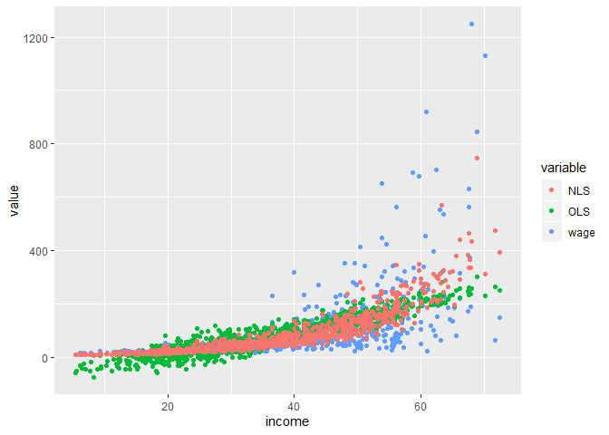

```r
# Predicted values
df$ols_predict <- predict(ols_results)
df$nls_predict <- predict(nls_results)

# Plot the predicted values
ggplot(df, aes(x=income, y=value, color=variable)) +
  geom_point(aes(y = wage, col="wage")) +
  geom_point(aes(y = ols_predict, col="OLS")) +
  geom_point(aes(y = nls_predict, col="NLS"))
```

Agora é com vocês… :)

# Lista 2

### Resposta binária parte I: Logit

Na aula, derivamos o score, a Hessiana condicional, e a distribuição assintótica (inclusive a variância assintótica) do estimador de Probit. Faça o mesmo para o Logit.

### Resposta binária parte II: função controle ou Limited Information Maximum Likelihood (LIML).

Considere agora o problema de estimar o modelo de variável latente: $Y_1 = 1 \left[ Y_1^* > 0 \right]$, com $Y_1^* = Y_2 \alpha + Z_1 \delta_1 + U$ e $Y_2 = Z \delta_2 + V$.

Suponha que a variável endógena $Y_2$ é contínua, $(U, V)$ seguem distribuição Normal bivariada com média zero, $Z$ (e portanto $Z_1 \subset Z$) é independente de $U$ e $V$, e os dois erros são possivelmente correlacionados (endogeneidade de $Y_2$). Normalize $\text{Var}(U) = 1$.

1. Escreva $U$ como função de $V$. Chame o desvio de $E$.
2. Use a equação acima para transformar as duas esquações estruturais em uma.
3. Qual a distribuição de $E$?
4. Termine a estimação de $Y_1$ sob essas condições.
5. Derive um teste de exogeneidade de $Y_2$. (Isto é, $H_0 : U \perp \!\!\! \perp V | Z = z$.) Sob que condições ele vai ser apropriado?

### Resposta binária parte III: IV Probit

[Continuação.] Consideremos agora uma forma mais direta de atacar o problema da questão anterior, estimando diretamente a função de verossimilhança condicional de $f(y_1, y_2 | Z = z)$.

1. Escreva $f(y_1, y_2 \ | Z = z)$ como função das densidades condicionais de $Y_1$ e $Y_2$ (dado $Z = z$).
2. Use (1) para derivar $f(y_1, y_2 | Z = z)$ (dadas as suposições do exercício anterior).
3. Defina o estimador de MLE para $f(y_1, y_2 | Z = z)$. Calcule a variância assintótica do estimador. Este estimador é o IV Probit.
4. Qual estimador usa mais informação, o IV Probit ou a Função Controle? Por que?
5. Qual seria um teste natural de exogeneidade nesse cenário? Derive sua distribuição.

### Modelo de resposta de canto: modelo de normal truncada.

Como vimos em aula, o modelo Tobit Tipo I implica efeitos parciais similares (em sinal e relativos) nas margens intensiva e extensiva de participação, o que pode ser indesejável em alguns casos. A forma mais simples de extender o Tobit Tipo I para permitir efeitos parciais diferentes em diferentes margens é assumir que dadas as covariadas, a decisão de participação é independente da decisão do montante escolhido, e portanto podem ser efetivamente tratadas como escolhas diferentes.

Considere o modelo $Y = SW^*$, onde $S \in \{ 0, 1 \}$ e $W^* \in \mathbb{R}_+$ só é observável quando $S = 1$. Assuma que $\text{Pr}(S = 1 | X = x) = \Phi (x\gamma)$, e que $W^* = X\beta + U$, com $U | X = x$ seguindo uma distribuição Normal truncada em $-x\beta$.

1. Derive $f(y \ | X = x, Y > 0)$.
2. Derive $f(y \ | X = x)$ e a função objetivo do estimador de MLE.
3. Calcule as esperanças condicionais ($| X = x$ e $| X = x, Y > 0$) e os efeitos parciais.
4. Que modo você pode testar se as margens intensiva e extensiva são diferentes?

### Parte aplicada: Probit

Queremos estimar um modelo com equação estrutural da forma $Y = 1\{X \beta + U > 0\}$, com $Y$ sendo estar empregado (*employed*) e $X$ contendo as mesmas variáveis independentes da Lista 1. Assuma que $U$ segue uma distribuição Normal padrão (i.i.d.), e portanto a equação estrutural é $\Pr (Y = 1 | X = x) = \Phi (x \beta)$.

1. Estime os coeficientes $\beta$ por MLE (Probit). Estime a matriz de variância-covariância (assintótica) e cheque quais coeficientes são estatísticamente diferentes de zero.
2. Estime os efeitos parciais na média e média dos efeitos marginais, assim como a sua variância (assintótica). Interprete os resultados.
3. Estime um OLS (usando o método “lm”) e compare os resultados.
4. Realize um teste de Razão de Verossimilhança (LR) sobre a hipótese da idade (“age”) afetar a probabilidade de estar empregado.
5. Realize um teste de Vuong (1989) sobre se o modelo Probit que você estimou é mais corretamente especificado que um Logit. (Para estimar o modelo Logit vocês podem usar funções automatizadas.)

**Observação importante:** O exercício é simples exatamente para possibilitar o não-uso de funções pré-programadas nos softwares estatísticos. Use as equações vistas em aula/no livro diretamente.

A resposta da aplicação envolve: 1. as respostas em si; 2. explicação (sucinta) do método de estimação utilizado; 3. o código utilizado.

#### Preparação dos dados:

```r
# We need to add the dependent variable to the data

# True parameters
true_beta = c(-25.0, 0.3, 8.0, -0.05, 13.0, 16.0, 22.0)

# Now we build the binary outcome variable
# Note that the true DGP is logistic
U <- rlogis(n = 1000, location = 0, scale = 10)
df$employed = ifelse(true_beta[1] + df$income * true_beta[2] + df$vote_share * true_beta[3] + df$age * true_beta[4] +
          df$race_b * true_beta[5] + df$race_c * true_beta[6] + df$race_d * true_beta[7] + U > 0, 1, 0)
```

Acima simulamos os dados para a Lista 2 (para além dos dados da Lista 1, que continuam a ser usados).

```r
# Agora rodemos o Probit
probit_results <- glm(employed ~ income + vote_share + age + race,
                     data=df,
                     family = binomial(link = "probit")
)
kable(summary(probit_results)$coef, digits = 2) %>% kable_styling()
```

|  | Estimate | Std. Error | z value | Pr(>\|z\|) |
| --- | --- | --- | --- | --- |
| (Intercept) | -1.33 | 0.36 | -3.70 | 0.00 |
| income | 0.03 | 0.01 | 4.43 | 0.00 |
| vote_share | 0.56 | 0.15 | 3.68 | 0.00 |
| age | -0.01 | 0.01 | -1.78 | 0.07 |
| raceb | 0.79 | 0.14 | 5.75 | 0.00 |
| racec | 0.77 | 0.17 | 4.58 | 0.00 |
| raced | 1.12 | 0.21 | 5.20 | 0.00 |

```r
# Esses são coeficientes apenas! Não tem interpretação. Queremos os efeitos marginais.
probitmfx(employed ~ income + vote_share + age + race, data=df, atmean=TRUE) # Efeitos marginais na média
```

```
## Call:
## probitmfx(formula = employed ~ income + vote_share + age + race,
##     data = df, atmean = TRUE)
##
## Marginal Effects:
##                 dF/dx  Std. Err.       z     P>|z|
## income      0.0102607  0.0023175  4.4276 9.530e-06 ***
## vote_share  0.2217380  0.0603101  3.6766 0.0002363 ***
## age        -0.0045604  0.0025551 -1.7848 0.0742890 .
## raceb       0.3046019  0.0491703  6.1948 5.834e-10 ***
## racec       0.2964106  0.0601767  4.9257 8.407e-07 ***
## raced       0.4131311  0.0677229  6.1003 1.059e-09 ***
## ---
## Signif. codes:  0 '***' 0.001 '**' 0.01 '*' 0.05 '.' 0.1 ' ' 1
##
## dF/dx is for discrete change for the following variables:
##
## [1] "raceb" "racec" "raced"
```

```r
probitmfx(employed ~ income + vote_share + age + race, data=df, atmean=FALSE) # Média dos efeitos marginais
```

```
## Call:
## probitmfx(formula = employed ~ income + vote_share + age + race,
##     data = df, atmean = FALSE)
##
## Marginal Effects:
##                 dF/dx  Std. Err.       z     P>|z|
## income      0.0081411  0.0017878  4.5537 5.272e-06 ***
## vote_share  0.1759321  0.0469642  3.7461 0.0001796 ***
## age        -0.0036184  0.0020186 -1.7925 0.0730449 .
## raceb       0.2302553  0.0341951  6.7336 1.655e-11 ***
## racec       0.2368891  0.0468769  5.0534 4.339e-07 ***
## raced       0.3636392  0.0617775  5.8863 3.950e-09 ***
## ---
## Signif. codes:  0 '***' 0.001 '**' 0.01 '*' 0.05 '.' 0.1 ' ' 1
##
## dF/dx is for discrete change for the following variables:
##
## [1] "raceb" "racec" "raced"
```

Acima eu calculei usando os pacotes estatísticos padrão no R. Não vou repetir o começo do código que coloquei na lista anterior.

# Lista 3

### Método dos momentos parte I: o GMM Probit.

Na aula derivamos os estimadores do Probit e Logit por MLE, que é reconhecidamente o método mais comum. Mas certamente não é o único!

1. Descreva o estimador de Logit por GMM dada a especicaçãao correta da esperança condicional de $Y | X = x$. (Observação: Vimos em sala que podemos escrever todo MLE como um MM (ou GMM). Estou pedindo o estimador de informação limitada usando momentos da esperança condicional.) Faça o mesmo para o Probit. Eles são iguais ao estimador de MLE?
2. Se $X = (X_1; X_2)$ e $X_1$ for endógeno, e se tivermos um instrumento adequado Z (que inclua $X_2$), a princípio poderíamos tentar estimar um Probit com instrumentos usando momentos análogos ao de (a), mas com Z ao invés de X. (Isto é, de forma análoga à relação do IV com o OLS.) Acontece que esse estimador não é consistente. Demonstre esse resultado.

### Método dos momentos parte II: o estimador de distância mínima clássico

Considere um problema de regressão com a equação estrutural não-linear nos parâmetros:

$$Y = X g(\theta_0) + U$$
onde $g:\mathbb{R}^P \rightarrow \mathbb{R}^K$ é uma função conhecida e continuamente diferenciável. Responda:

1. Como você estimaria $\theta_0$ usando método dos momentos?
2. E usando o estimador de distância mínima (clássico)?

### Bootstrap parte I: consistência

Para um estimador arbitrário $\hat{\theta}(x)$, onde $x = (x_1, ..., x_N)$ é uma amostra aleatória, o estimador de Bootstrap da variância de $\hat{\theta}(x)$, calculado em $B$ reamostragens com reposição, é dado por:
$$\widehat{\text{Var}_{B}}(\hat{\theta}) = \frac{1}{B - 1} \sum_{b = 1}^{B} ( \hat{\theta}^b_B - \bar{\hat{\theta}}_B )^2$$

Use a Lei dos Grandes Números para mostrar que quando $B \rightarrow \infty$, $\widehat{\text{Var}_{B}}(\hat{\theta})$ converge para o estimador de Bootstrap de amostra completa:

$$Var^*(\hat{\theta}) = \frac{1}{N^N - 1} \sum_{i = 1}^{N} ( \hat{\theta}^i_B - \bar{\hat{\theta}}_B )^2,$$
onde $\bar{\hat{\theta}}_B = N^{-N} \sum_{i=1}^{N^N} \hat{\theta}^i_B$ é a média do estimador entre todas as $N^N$ possíveis reamostragens.

### Parte Aplicada: Bootstrap.

Para o modelo e base de dados da Lista 2, calcule: 1. O desvio-padrão do estimador MLE de $\beta$ por bootstrap não-paramétrico e bootstrap paramétrico. 2. Um intervalo de confiança de 5%, e os bootstrap p-values. Use o método do percentil-t. Compare com os resultados da lista anterior.

**Observação importante:** O exercício é simples exatamente para possibilitar o não-uso de funções pré-programadas nos softwares estatísticos. Use as equações vistas em aula/no livro diretamente.

A resposta da aplicação envolve: 1. as respostas em si; 2. explicação (sucinta) do método de estimação utilizado; 3. o código utilizado.